# Regression Model Selection (step-by-step) on Covid-19 Vaccination Progress Worldwide dataset

Since I started learning Machine Learning and the great diversity of models available to fit my data, I started asking myself the big question of: *okay, I know I should use a Regression Model for numerical predictions but, which of these models should I choose for my data?* Well, don't worry, I'll show you **one way** to approach this question and come up with a decent result that you could use for all your regression problems. The process I follow at the moment is:

- 1. Importing the required libraries
- 1. Importing my dataset (usually a csv file)
- 1. Preprocessing the data (taking care of missing values and encoding categorical data)
- 1. Splitting the dataset into the Training set and Test set (optional)
- 1. Training and testing each Regression model I want to evaluate
- 1. Evaluating the Model Performance (for each model)
- 1. Selecting the winner! (The model with the r squared value closer to 1)

Without further ado, let's get hands on an example of this process for better illustration of the process.

## Importing the libraries

For this specific application, and I believe it can also be the case for yours, the following libraries are needed:

```python
import pandas as pd # to import the dataset
import numpy as np # to handle matrices
import matplotlib.pyplot as plt # to plot
```

## Importing the data

You can find the dataset i'm using here with the title of **COVID-19 World Vaccination Progress** in kaggle (https://www.kaggle.com/gpreda/covid-world-vaccination-progress), which provides the Daily and Total Vaccination for COVID-19 in the World

```python
dataset = pd.read_csv("country_vaccinations.csv")
dataset.head(10) # we check the first 10 rows of our dataset
```

|  | country | iso_code | date | total_vaccinations | people_vaccinated | people_fully_vaccinated | daily_vaccinations_raw | daily_vaccinations | total_vaccinations_per_hundred | people_vaccinated_per_hundred | people_fully_vaccinated_per_hundred | daily_vaccinations_per_million | vaccines | source_name | source_website |
| --- | --- | --- | --- | --- | --- | --- | --- | --- | --- | --- | --- | --- | --- | --- | --- |
| 0 | Albania | ALB | 2021-01-10 | 0.0 | 0.0 | NaN | NaN | NaN | 0.00 | 0.00 | NaN | NaN | Pfizer/BioNTech | Ministry of Health | https://shendetesia.gov.al/covid19-ministria-e... |
| 1 | Albania | ALB | 2021-01-11 | NaN | NaN | NaN | NaN | 64.0 | NaN | NaN | NaN | 22.0 | Pfizer/BioNTech | Ministry of Health | https://shendetesia.gov.al/covid19-ministria-e... |
| 2 | Albania | ALB | 2021-01-12 | 128.0 | 128.0 | NaN | NaN | 64.0 | 0.00 | 0.00 | NaN | 22.0 | Pfizer/BioNTech | Ministry of Health | https://shendetesia.gov.al/covid19-ministria-e... |
| 3 | Albania | ALB | 2021-01-13 | 188.0 | 188.0 | NaN | 60.0 | 63.0 | 0.01 | 0.01 | NaN | 22.0 | Pfizer/BioNTech | Ministry of Health | https://shendetesia.gov.al/covid19-ministria-e... |
| 4 | Albania | ALB | 2021-01-14 | 266.0 | 266.0 | NaN | 78.0 | 66.0 | 0.01 | 0.01 | NaN | 23.0 | Pfizer/BioNTech | Ministry of Health | https://shendetesia.gov.al/covid19-ministria-e... |
| 5 | Albania | ALB | 2021-01-15 | 308.0 | 308.0 | NaN | 42.0 | 62.0 | 0.01 | 0.01 | NaN | 22.0 | Pfizer/BioNTech | Ministry of Health | https://shendetesia.gov.al/covid19-ministria-e... |
| 6 | Albania | ALB | 2021-01-16 | 369.0 | 369.0 | NaN | 61.0 | 62.0 | 0.01 | 0.01 | NaN | 22.0 | Pfizer/BioNTech | Ministry of Health | https://shendetesia.gov.al/covid19-ministria-e... |
| 7 | Albania | ALB | 2021-01-17 | 405.0 | 405.0 | NaN | 36.0 | 58.0 | 0.01 | 0.01 | NaN | 20.0 | Pfizer/BioNTech | Ministry of Health | https://shendetesia.gov.al/covid19-ministria-e... |
| 8 | Albania | ALB | 2021-01-18 | 447.0 | 447.0 | NaN | 42.0 | 55.0 | 0.02 | 0.02 | NaN | 19.0 | Pfizer/BioNTech | Ministry of Health | https://shendetesia.gov.al/covid19-ministria-e... |
| 9 | Albania | ALB | 2021-01-19 | 483.0 | 483.0 | NaN | 36.0 | 51.0 | 0.02 | 0.02 | NaN | 18.0 | Pfizer/BioNTech | Ministry of Health | https://shendetesia.gov.al/covid19-ministria-e... |

```python
dataset.columns # we read the column names
```

```
Index(['country', 'iso_code', 'date', 'total_vaccinations',
       'people_vaccinated', 'people_fully_vaccinated',
       'daily_vaccinations_raw', 'daily_vaccinations',
       'total_vaccinations_per_hundred', 'people_vaccinated_per_hundred',
       'people_fully_vaccinated_per_hundred', 'daily_vaccinations_per_million',
       'vaccines', 'source_name', 'source_website'],
      dtype='object')
```

As i'm planning to predict the **total vaccinations (y)** based on the other **features of the dataset (x)**, where x is my independent variable (in this case, more than one) and y is the dependent variable.

```python
x_df = dataset[['country', 'date','daily_vaccinations_raw', 'daily_vaccinations','total_vaccinations_per_hundred', 'people_vaccinated_per_hundred',
       'people_fully_vaccinated_per_hundred', 'daily_vaccinations_per_million','vaccines']] # independent variables
y_df = dataset[['total_vaccinations']] # dependent variable

x = x_df.values # as array
y = y_df.values # as array
```

```python
x[0:10,:] # we check the first 10 rows of our array x
```

```
array([['Albania', '2021-01-10', nan, nan, 0.0, 0.0, nan, nan,
        'Pfizer/BioNTech'],
       ['Albania', '2021-01-11', nan, 64.0, nan, nan, nan, 22.0,
        'Pfizer/BioNTech'],
       ['Albania', '2021-01-12', nan, 64.0, 0.0, 0.0, nan, 22.0,
        'Pfizer/BioNTech'],
       ['Albania', '2021-01-13', 60.0, 63.0, 0.01, 0.01, nan, 22.0,
        'Pfizer/BioNTech'],
       ['Albania', '2021-01-14', 78.0, 66.0, 0.01, 0.01, nan, 23.0,
        'Pfizer/BioNTech'],
       ['Albania', '2021-01-15', 42.0, 62.0, 0.01, 0.01, nan, 22.0,
        'Pfizer/BioNTech'],
       ['Albania', '2021-01-16', 61.0, 62.0, 0.01, 0.01, nan, 22.0,
        'Pfizer/BioNTech'],
       ['Albania', '2021-01-17', 36.0, 58.0, 0.01, 0.01, nan, 20.0,
        'Pfizer/BioNTech'],
       ['Albania', '2021-01-18', 42.0, 55.0, 0.02, 0.02, nan, 19.0,
        'Pfizer/BioNTech'],
       ['Albania', '2021-01-19', 36.0, 51.0, 0.02, 0.02, nan, 18.0,
        'Pfizer/BioNTech']], dtype=object)
```

```python
y[0:10,:] # we check the first 10 rows of our array y
```

```
array([[  0.],
       [ nan],
       [128.],
       [188.],
       [266.],
       [308.],
       [369.],
       [405.],
       [447.],
       [483.]])
```

## Taking care of missing data

We notice that the dataset has some 'NaN' values, which we can not use to train and test our model, so **we need to normalize** them, although deleting them is also an option, we will replace them using the SimpleImputer class.

```python
from sklearn.impute import SimpleImputer # importing the SimpleImputer class that let's us replace the missing values
                                         # with the average of the column

imputer = SimpleImputer(missing_values= np.nan, strategy="mean")
```

Applied to x:

```python
imputer.fit(X = x[:, 2:8]) # expects only the numerical values columns, not the category ones

x[:,2:8] = imputer.transform(x[:,2:8]) # we replace the missing values on the original array
x[0:10,:]
```

```
array([['Albania', '2021-01-10', 74045.48985801217, 57184.43567251462,
        0.0, 0.0, 1.7913693270735522, 2284.0280701754386,
        'Pfizer/BioNTech'],
       ['Albania', '2021-01-11', 74045.48985801217, 64.0,
        6.074087996582658, 5.177969072164948, 1.7913693270735522, 22.0,
        'Pfizer/BioNTech'],
       ['Albania', '2021-01-12', 74045.48985801217, 64.0, 0.0, 0.0,
        1.7913693270735522, 22.0, 'Pfizer/BioNTech'],
       ['Albania', '2021-01-13', 60.0, 63.0, 0.01, 0.01,
        1.7913693270735522, 22.0, 'Pfizer/BioNTech'],
       ['Albania', '2021-01-14', 78.0, 66.0, 0.01, 0.01,
        1.7913693270735522, 23.0, 'Pfizer/BioNTech'],
       ['Albania', '2021-01-15', 42.0, 62.0, 0.01, 0.01,
        1.7913693270735522, 22.0, 'Pfizer/BioNTech'],
       ['Albania', '2021-01-16', 61.0, 62.0, 0.01, 0.01,
        1.7913693270735522, 22.0, 'Pfizer/BioNTech'],
       ['Albania', '2021-01-17', 36.0, 58.0, 0.01, 0.01,
        1.7913693270735522, 20.0, 'Pfizer/BioNTech'],
       ['Albania', '2021-01-18', 42.0, 55.0, 0.02, 0.02,
        1.7913693270735522, 19.0, 'Pfizer/BioNTech'],
       ['Albania', '2021-01-19', 36.0, 51.0, 0.02, 0.02,
        1.7913693270735522, 18.0, 'Pfizer/BioNTech']], dtype=object)
```

Applied to y:

```python
imputer.fit(X = y) # expects only the numerical values columns, not the category ones

y = imputer.transform(y) # we replace the missing values on the original array
y[0:10,:]
```

```
array([[0.00000000e+00],
       [1.48631876e+06],
       [1.28000000e+02],
       [1.88000000e+02],
       [2.66000000e+02],
       [3.08000000e+02],
       [3.69000000e+02],
       [4.05000000e+02],
       [4.47000000e+02],
       [4.83000000e+02]])
```

## Encoding categorical data

In order to train our models with categorical data, we need to **encode** the categories into "dummy variables", this needs to be done because we can not train regression models directly with strings.

```python
x_df = pd.DataFrame(x, columns = ['country', 'date','daily_vaccinations_raw', 'daily_vaccinations','total_vaccinations_per_hundred', 'people_vaccinated_per_hundred','people_fully_vaccinated_per_hundred', 'daily_vaccinations_per_million','vaccines'])
x_df
```

|  | country | date | daily_vaccinations_raw | daily_vaccinations | total_vaccinations_per_hundred | people_vaccinated_per_hundred | people_fully_vaccinated_per_hundred | daily_vaccinations_per_million | vaccines |
| --- | --- | --- | --- | --- | --- | --- | --- | --- | --- |
| 0 | Albania | 2021-01-10 | 74045.489858 | 57184.435673 | 0.0 | 0.0 | 1.791369 | 2284.02807 | Pfizer/BioNTech |
| 1 | Albania | 2021-01-11 | 74045.489858 | 64.0 | 6.074088 | 5.177969 | 1.791369 | 22.0 | Pfizer/BioNTech |
| 2 | Albania | 2021-01-12 | 74045.489858 | 64.0 | 0.0 | 0.0 | 1.791369 | 22.0 | Pfizer/BioNTech |
| 3 | Albania | 2021-01-13 | 60.0 | 63.0 | 0.01 | 0.01 | 1.791369 | 22.0 | Pfizer/BioNTech |
| 4 | Albania | 2021-01-14 | 78.0 | 66.0 | 0.01 | 0.01 | 1.791369 | 23.0 | Pfizer/BioNTech |
| ... | ... | ... | ... | ... | ... | ... | ... | ... | ... |
| 3550 | Wales | 2021-02-14 | 13987.0 | 26206.0 | 25.06 | 24.89 | 0.17 | 8312.0 | Oxford/AstraZeneca, Pfizer/BioNTech |
| 3551 | Wales | 2021-02-15 | 12967.0 | 24418.0 | 25.47 | 25.24 | 0.23 | 7745.0 | Oxford/AstraZeneca, Pfizer/BioNTech |
| 3552 | Wales | 2021-02-16 | 17161.0 | 23033.0 | 26.02 | 25.61 | 0.41 | 7305.0 | Oxford/AstraZeneca, Pfizer/BioNTech |
| 3553 | Wales | 2021-02-17 | 21636.0 | 22012.0 | 26.7 | 26.09 | 0.61 | 6982.0 | Oxford/AstraZeneca, Pfizer/BioNTech |
| 3554 | Wales | 2021-02-18 | 22523.0 | 20649.0 | 27.42 | 26.61 | 0.81 | 6549.0 | Oxford/AstraZeneca, Pfizer/BioNTech |

3555 rows × 9 columns

```python
x_df_nodummies = x_df
x_df = pd.get_dummies(x_df, columns=["date","country", "vaccines"], prefix=["date","country", "vaccines"]) # now, x_df has the dummy variables
```

```python
x_df # we verify th structure with the dummy variables
```

|  | daily_vaccinations_raw | daily_vaccinations | total_vaccinations_per_hundred | people_vaccinated_per_hundred | people_fully_vaccinated_per_hundred | daily_vaccinations_per_million | date_2020-12-13 | date_2020-12-14 | date_2020-12-15 | date_2020-12-16 | ... | vaccines_Oxford/AstraZeneca, Sinovac | vaccines_Oxford/AstraZeneca, Sputnik V | vaccines_Pfizer/BioNTech | vaccines_Pfizer/BioNTech, Sinopharm/Beijing | vaccines_Pfizer/BioNTech, Sinopharm/Beijing, Sputnik V | vaccines_Pfizer/BioNTech, Sinovac | vaccines_Sinopharm/Beijing | vaccines_Sinopharm/Beijing, Sinopharm/Wuhan, Sinovac | vaccines_Sinovac | vaccines_Sputnik V |
| --- | --- | --- | --- | --- | --- | --- | --- | --- | --- | --- | --- | --- | --- | --- | --- | --- | --- | --- | --- | --- | --- |
| 0 | 74045.489858 | 57184.435673 | 0.0 | 0.0 | 1.791369 | 2284.02807 | 0 | 0 | 0 | 0 | ... | 0 | 0 | 1 | 0 | 0 | 0 | 0 | 0 | 0 | 0 |
| 1 | 74045.489858 | 64.0 | 6.074088 | 5.177969 | 1.791369 | 22.0 | 0 | 0 | 0 | 0 | ... | 0 | 0 | 1 | 0 | 0 | 0 | 0 | 0 | 0 | 0 |
| 2 | 74045.489858 | 64.0 | 0.0 | 0.0 | 1.791369 | 22.0 | 0 | 0 | 0 | 0 | ... | 0 | 0 | 1 | 0 | 0 | 0 | 0 | 0 | 0 | 0 |
| 3 | 60.0 | 63.0 | 0.01 | 0.01 | 1.791369 | 22.0 | 0 | 0 | 0 | 0 | ... | 0 | 0 | 1 | 0 | 0 | 0 | 0 | 0 | 0 | 0 |
| 4 | 78.0 | 66.0 | 0.01 | 0.01 | 1.791369 | 23.0 | 0 | 0 | 0 | 0 | ... | 0 | 0 | 1 | 0 | 0 | 0 | 0 | 0 | 0 | 0 |
| ... | ... | ... | ... | ... | ... | ... | ... | ... | ... | ... | ... | ... | ... | ... | ... | ... | ... | ... | ... | ... | ... |
| 3550 | 13987.0 | 26206.0 | 25.06 | 24.89 | 0.17 | 8312.0 | 0 | 0 | 0 | 0 | ... | 0 | 0 | 0 | 0 | 0 | 0 | 0 | 0 | 0 | 0 |
| 3551 | 12967.0 | 24418.0 | 25.47 | 25.24 | 0.23 | 7745.0 | 0 | 0 | 0 | 0 | ... | 0 | 0 | 0 | 0 | 0 | 0 | 0 | 0 | 0 | 0 |
| 3552 | 17161.0 | 23033.0 | 26.02 | 25.61 | 0.41 | 7305.0 | 0 | 0 | 0 | 0 | ... | 0 | 0 | 0 | 0 | 0 | 0 | 0 | 0 | 0 | 0 |
| 3553 | 21636.0 | 22012.0 | 26.7 | 26.09 | 0.61 | 6982.0 | 0 | 0 | 0 | 0 | ... | 0 | 0 | 0 | 0 | 0 | 0 | 0 | 0 | 0 | 0 |
| 3554 | 22523.0 | 20649.0 | 27.42 | 26.61 | 0.81 | 6549.0 | 0 | 0 | 0 | 0 | ... | 0 | 0 | 0 | 0 | 0 | 0 | 0 | 0 | 0 | 0 |

3555 rows × 191 columns

```python
x = x_df.values # convertind the data frame into an array
x
```

```
array([[74045.48985801217, 57184.43567251462, 0.0, ..., 0, 0, 0],
       [74045.48985801217, 64.0, 6.074087996582658, ..., 0, 0, 0],
       [74045.48985801217, 64.0, 0.0, ..., 0, 0, 0],
       ...,
       [17161.0, 23033.0, 26.02, ..., 0, 0, 0],
       [21636.0, 22012.0, 26.7, ..., 0, 0, 0],
       [22523.0, 20649.0, 27.42, ..., 0, 0, 0]], dtype=object)
```

```python
y
```

```
array([[0.00000000e+00],
       [1.48631876e+06],
       [1.28000000e+02],
       ...,
       [8.20339000e+05],
       [8.41975000e+05],
       [8.64498000e+05]])
```

## Splitting the dataset into the Training set and Test set

Let's create our train and test arrays with 20% of the data corresponding to the test array.

```python
from sklearn.model_selection import train_test_split
x_train, x_test, y_train, y_test = train_test_split(x, y, test_size = 0.2, random_state = 1)
```

```python
len(x_train) # verifying its size
```

```
2844
```

```python
len(x_test) # verifying its size
```

```
711
```

# Regression Model Application

## 1. **Multiple Linear Regression**

### Training the Multiple Linear Regression model on the Training set

```python
from sklearn.linear_model import LinearRegression

regressor = LinearRegression()
regressor.fit(x_train, y_train)
```

```
LinearRegression()
```

### Predicting the Test set results

We test the trained model with the test data and concatenate it in an array for easy comparison

```python
y_pred = regressor.predict(x_test)
np.set_printoptions(precision = 0)
print(np.concatenate((y_pred.reshape(len(y_pred),1), y_test.reshape(len(y_test),1)),1))
```

```
[[ 1.e+06  3.e+04]
 [-8.e+05  0.e+00]
 [ 5.e+06  5.e+06]
 ...
 [-1.e+05  9.e+04]
 [ 2.e+07  2.e+07]
 [-2.e+05  2.e+04]]
```

### Evaluating the Model Performance

We obtain an r squared of 0.82, meaning a fit of 82%

```python
from sklearn.metrics import r2_score
r2_score(y_test, y_pred)
```

```
0.820361971864213
```

## 2. Polynomial Regression

### Training the Polynomial Regression model on the Training set

```python
from sklearn.preprocessing import PolynomialFeatures
from sklearn.linear_model import LinearRegression

poly_reg = PolynomialFeatures(degree = 2)
x_poly = poly_reg.fit_transform(x_train)
regressor = LinearRegression()
regressor.fit(x_poly, y_train)
```

```
LinearRegression()
```

### Predicting the Test set results

```python
y_pred = regressor.predict(poly_reg.transform(x_test))
np.set_printoptions(precision=2)
print(np.concatenate((y_pred.reshape(len(y_pred),1), y_test.reshape(len(y_test),1)),1))
```

```
[[-5.50e+03  3.20e+04]
 [-2.63e+08  0.00e+00]
 [ 7.68e+06  5.30e+06]
 ...
 [ 5.99e+04  9.13e+04]
 [ 2.42e+07  2.27e+07]
 [ 2.23e+04  1.93e+04]]
```

### Evaluating the Model Performance

```python
from sklearn.metrics import r2_score
r2_score(y_test, y_pred)
```

```
-275.73153181051356
```

This result means the performance of our model was really really bad.

## 3. Decision Tree Regression

## Training the model

```python
from sklearn.tree import DecisionTreeRegressor
regressor = DecisionTreeRegressor(random_state = 0)
regressor.fit(x_train, y_train)
```

```
DecisionTreeRegressor(random_state=0)
```

## Predicting the Test set results

```python
y_pred = regressor.predict(x_test)
np.set_printoptions(precision = 2)
print(np.concatenate((y_pred.reshape(len(y_pred),1), y_test.reshape(len(y_test),1)),1))
```

```
[[6.68e+02 3.20e+04]
 [0.00e+00 0.00e+00]
 [5.19e+06 5.30e+06]
 ...
 [8.80e+04 9.13e+04]
 [2.35e+07 2.27e+07]
 [2.20e+04 1.93e+04]]
```

## Evaluating Model Performance

```python
from sklearn.metrics import r2_score
r2_score(y_test, y_pred)
```

```
0.9627743674208652
```

We notice that our Decision Tree Regression model has a fit of 96%, which is actually pretty good!

# 4. Random Forest Regression

## Training the Random Forest Regression model

```python
from sklearn.ensemble import RandomForestRegressor
regressor = RandomForestRegressor(n_estimators = 10, random_state = 0)
regressor.fit(x_train, y_train)
```

## Predicting the Test set results

```python
y_pred = regressor.predict(x_test)
np.set_printoptions(precision=2)
print(np.concatenate((y_pred.reshape(len(y_pred),1), y_test.reshape(len(y_test),1)),1))
```

```
[[1.53e+05 3.20e+04]
 [0.00e+00 0.00e+00]
 [5.29e+06 5.30e+06]
 ...
 [1.28e+05 9.13e+04]
 [2.15e+07 2.27e+07]
 [2.11e+04 1.93e+04]]
```

## Evaluating the Model Performance

```python
from sklearn.metrics import r2_score
r2_score(y_test, y_pred)
```

```
0.9659467525523365
```

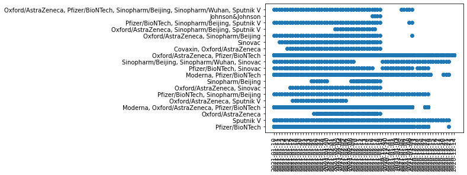

```python
plt.plot_date(x_df_nodummies.date, x_df_nodummies.vaccines)
plt.xticks(rotation ='vertical')
plt.show()
```

Finally, we observe that the winner of our previously tested regression models is the **Random Forest Regression model with a fit of 96.59%** which is really great! Now, you can be sure that this is the model that will perform better in case you want to make a prediction of the total vaccinations based on the features selected as predictors in x. **(Stay tuned for the part 2, where we will work a little bit more on the predictions and visualizations of the data)**. By the way, don't forget the performance of each model changes for each dataset, so you actually do need to compare them to select the best one for each case (hint: you can also change their performance by optimizing the default hyperparameters).

I really hope this data preprocessing focused project will be helpful for your own projects and makes a big difference on your **Regression Model Selection process** based on performance comparison, keep it up!